# Standard vs. Natural: Assessing the impact of environmental variables on organic matter decomposition in streams using three substrates

## 4.1 leaves vs. decotabs

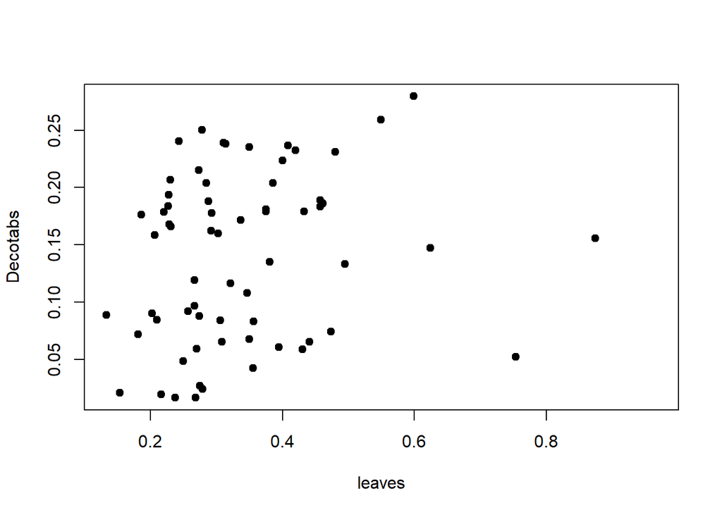

```r
plot(Decom_2019_all$DSM_leaves_coarse, Decom_2019_all$DSM_Decotabs_coarse, pch = 19, ylab = "Decotabs", xlab = "leaves")
```

```r
cor.test(Decom_2019_all$DSM_leaves_coarse, Decom_2019_all$DSM_Decotabs_coarse)$p.value
```

```
## [1] 0.1181976
```

```r
round(as.numeric(cor.test(Decom_2019_all$DSM_leaves_coarse, Decom_2019_all$DSM_Decotabs_coarse)$estimate)^2,3) # r2 = 0.038
```

```
## [1] 0.038
```

comparison over 66 observations from 31 sites

```r
data_macro <- Decom_2019_all[!is.na(Decom_2019_all$DSM_leaves_coarse), ]
data_macro <- data_macro[!is.na(data_macro$DSM_Decotabs_coarse), ]
```

## 4.2 create Figure 2 total decomposition relationships

```r
png(filename="Figure_2_substrate_comparison_total.png", width=3.5, height=3.5, units="in", res = 1000)

# Leaves vs. Decotabs
ggplot(data = Decom_2019_all, aes(x = DSM_leaves_coarse, y = DSM_Decotabs_coarse))+
  geom_point(size = 2) +
  ggtitle("") +
  ylab("Decomposed decotabs mass [%] per dday")+
  xlab("Decomposed leaf mass [%] per dday") +
  xlim(0.13, 0.9)+
  annotate("text", x = 0.85, y=0.25, label = paste("~italic(r)^2 ==",  0.04), parse=TRUE, size = 3.5)+
  annotate("text", x = 0.85, y=0.23, label = "italic(p) == 0.12", parse=TRUE, size = 3.5)+
  theme_classic()+
  theme(axis.text.x = element_text(colour="black", size = 12),
        axis.text.y = element_text(colour="black", size = 12),
        plot.subtitle = element_text(colour="black", size = 14),
        legend.position="none", strip.text.x = element_text(face = "bold"),
        text = element_text(size=11), plot.title = element_text(hjust = 0.5))


dev.off()
```

## 4.3 interrepicate variability

total leaves

```r
# absolute
mean(with(Decom_2019_all, tapply(DSM_leaves_coarse, siteID, var)), na.rm = TRUE) # 0.007914277
```

```
## [1] 0.007914277
```

```r
# relative [%]
mean(with(Decom_2019_all, tapply(DSM_leaves_coarse, siteID, var))/ with(Decom_2019_all, tapply(DSM_leaves_coarse, siteID, mean)), na.rm = TRUE)*100 # 1.73%
```

```
## [1] 1.733504
```

total decotabs

```r
# absolute
mean(with(Decom_2019_all, tapply(DSM_Decotabs_coarse, siteID, var)), na.rm = TRUE) # 0.0008586815
```

```
## [1] 0.0008586815
```

```r
# relative [%]
mean(with(Decom_2019_all, tapply(DSM_Decotabs_coarse, siteID, var))/ with(Decom_2019_all, tapply(DSM_Decotabs_coarse, siteID, mean)), na.rm = TRUE)*100 # 0.74 %
```

```
## [1] 0.7441896
```

# 5 Explanatory variables (agricultural stressors)

in the table exp_var we collected information on different variables that can drive the decomposition

## 5.1 remove unnecessary columns

at first remove those variables, which are not important for fungal communities / decomposition:  
* forest_perc  
* green_perc  
* for_buffer  
* grass_buffer

additionally exclude stream temperature (temp), since this is already included in the calculates decomposition

further remove those variables with a low value range / too many zero values:  
* Cd  
* Pb  
* spec_buffer  
* FU_rich_buffer  
* urban_perc

```r
rm_perc <- c("forest_per", "green_perc", "for_buffer", "grass_buffer",
             "temp",
             "Cd_t1", "Cd_t2", "Pb_t1", "Pb_t2", "spec_buffer", "FU_rich_buffer", "urban_perc")

exp_var <- exp_var[ , -which(names(exp_var) %in% rm_perc)]
```

## 5.2 transformation check

identify skewness variables with high positive values not normally distributed, have to be log transformed

```r
data_perc <- exp_var[,-1] # remove site ID

skew_perc <- NULL
for(i in 1:ncol(data_perc)) {
  colname <- names(data_perc)[i]
t <- skewness(select(data_perc, all_of(colname)), na.rm = TRUE)
skew_perc$variable[i] <- all_of(colname)
skew_perc$value[i] <- t
}
skew_perc <- as.data.frame(skew_perc)

# variables abbreviate more than 2 from zero likely need to be transformed, especially when variable is spanning over several orders of magnitude
var_transform <- skew_perc[sqrt((skew_perc$value)^2) > "2" , ]
var_transform$variable
```

```
##  [1] "area"             "CPOM"             "abu_shr"          "NO3_t1"
##  [5] "PO4_t1"           "NH4_t1"           "NO2_t2"           "NO3_t2"
##  [9] "PO4_t2"           "NH4_t2"           "TP_t1"            "TNb_t1"
## [13] "NP_ratio_t1"      "As_t1"            "Zn_t1"            "Hg_t1"
## [17] "TP_t2"            "TNb_t2"           "NP_ratio_t2"      "Zn_t2"
## [21] "Hg_t2"            "sumTU_fu_date_t2"
```

check histograms

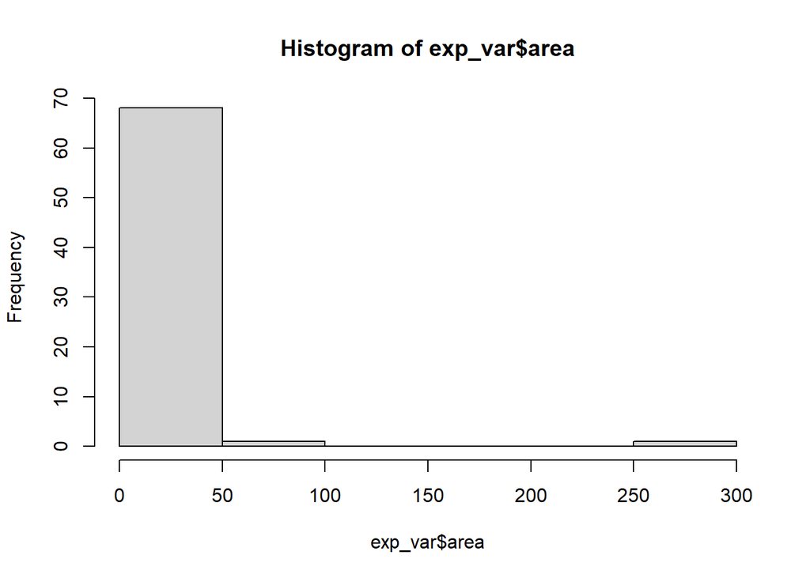

```r
hist(exp_var$area)
```

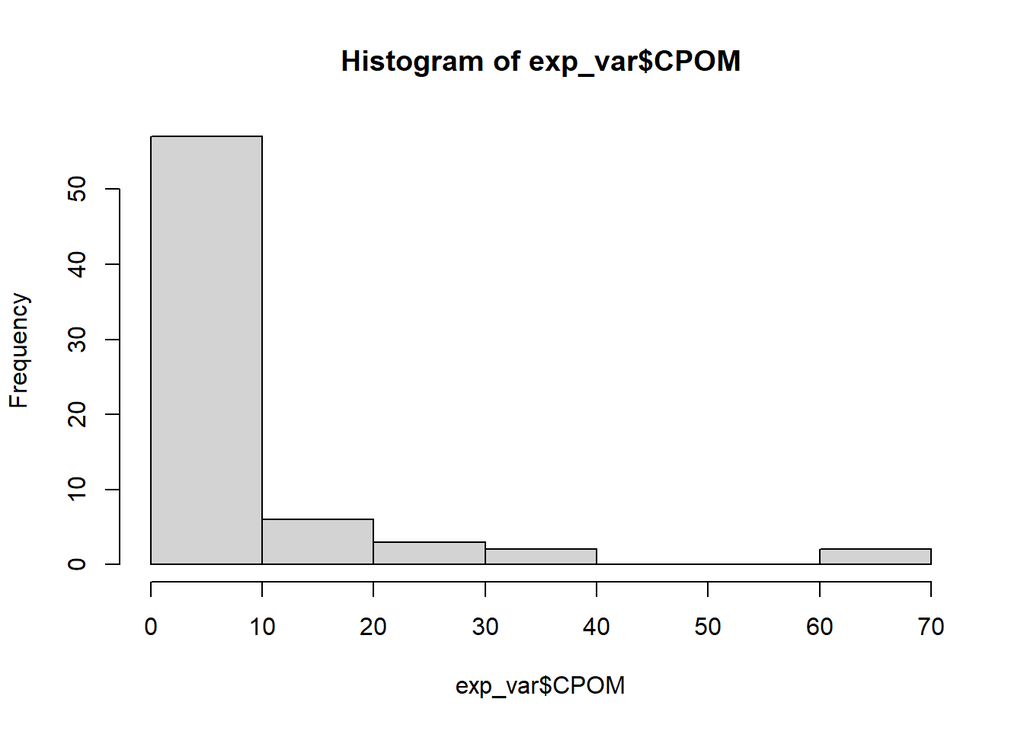

```r
hist(exp_var$CPOM)
```

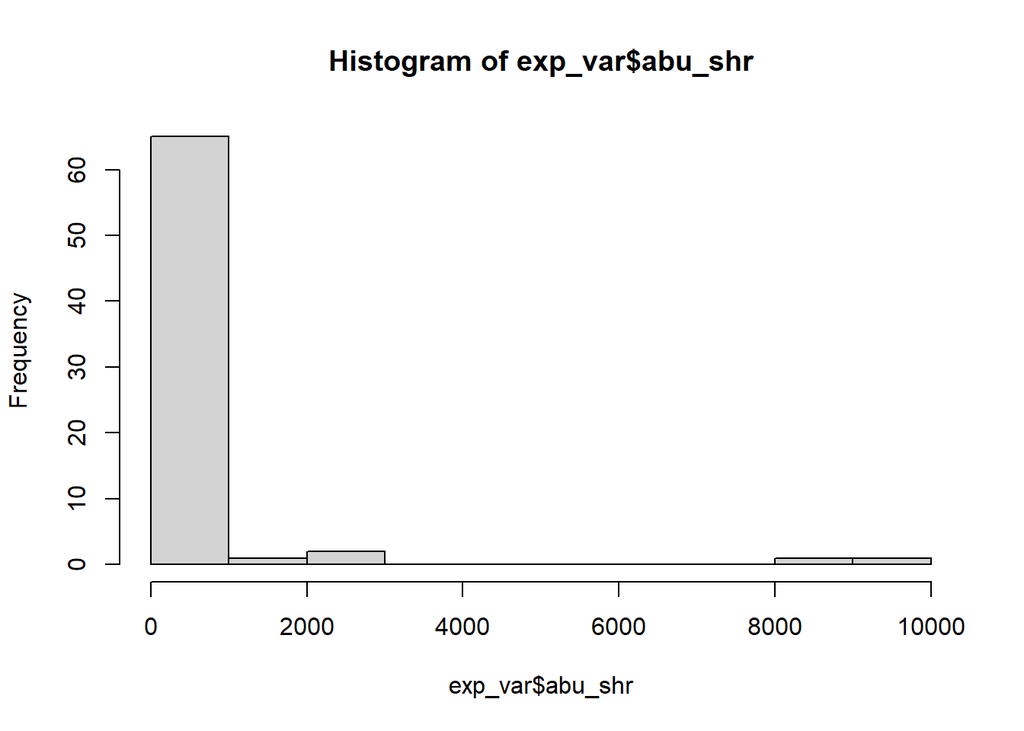

```r
hist(exp_var$abu_shr)
```

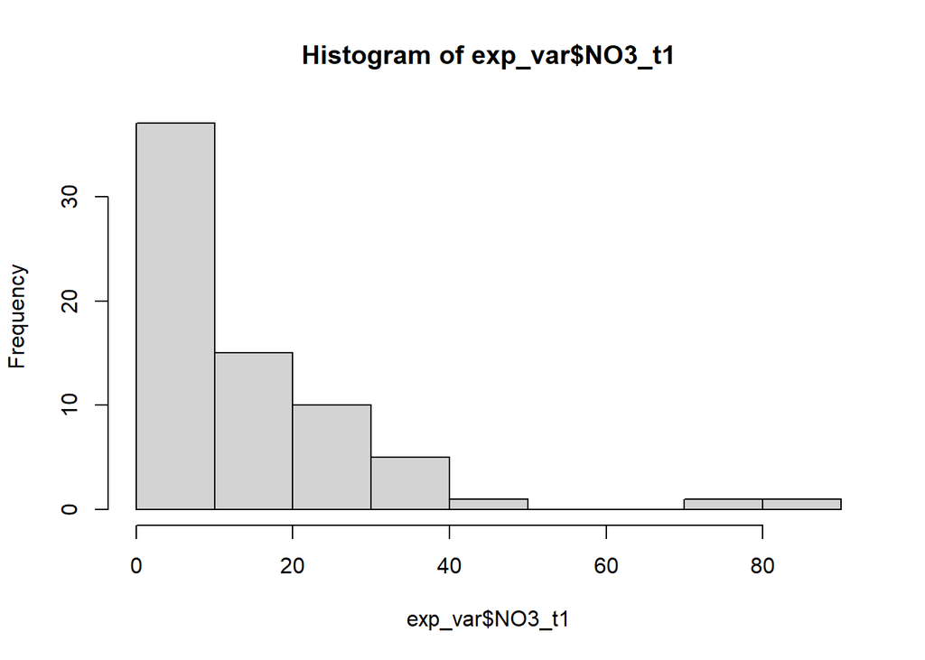

```r
hist(exp_var$NO3_t1)
```

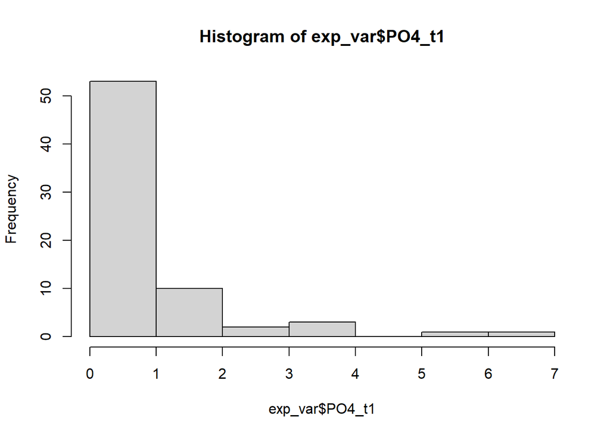

```r
hist(exp_var$PO4_t1)
```

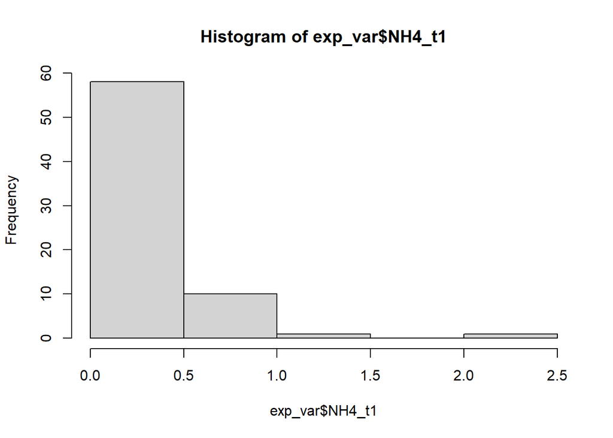

```r
hist(exp_var$NH4_t1)
```

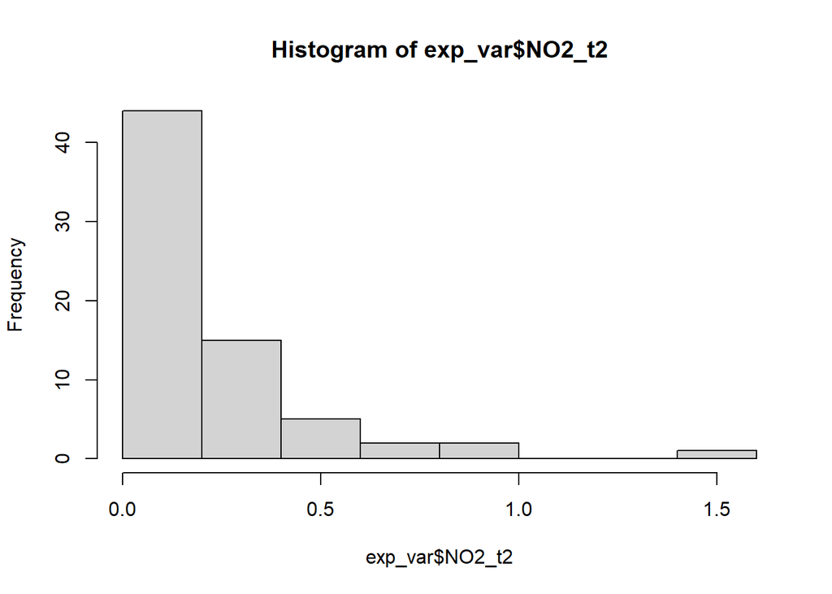

```r
hist(exp_var$NO2_t2)
```

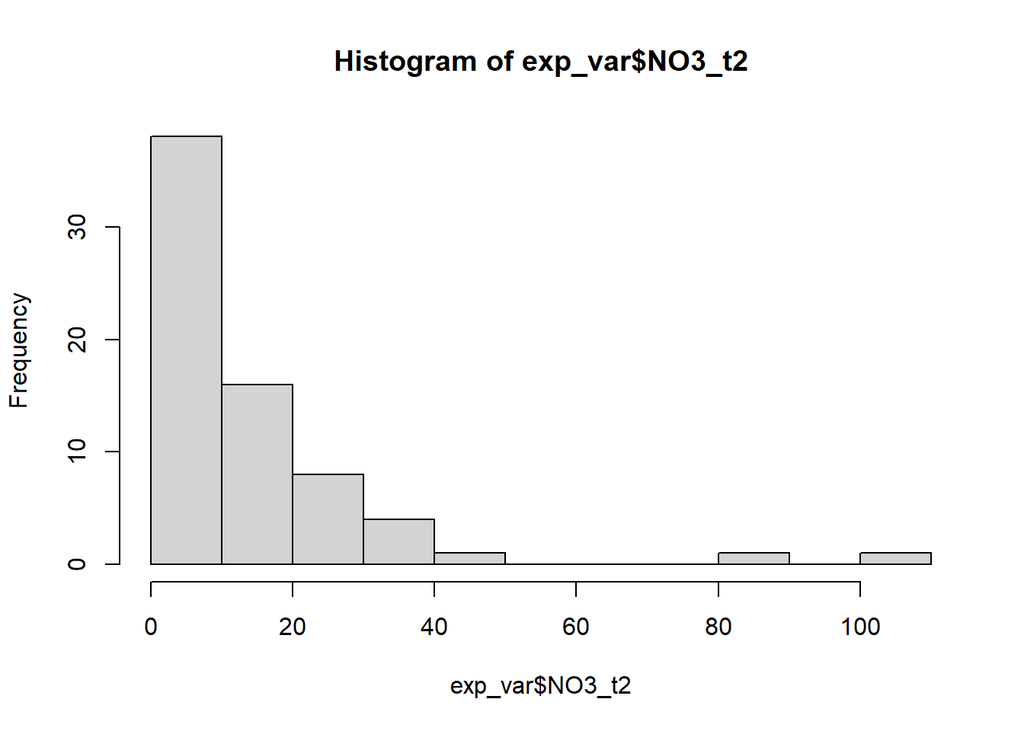

```r
hist(exp_var$NO3_t2)
```

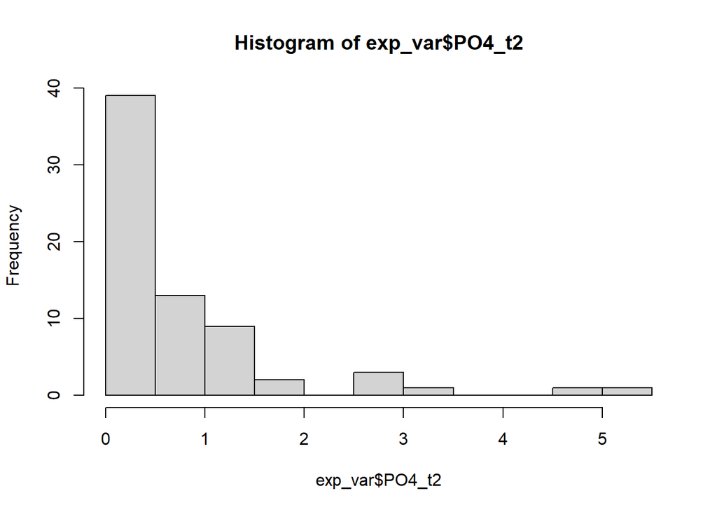

```r
hist(exp_var$PO4_t2)
```

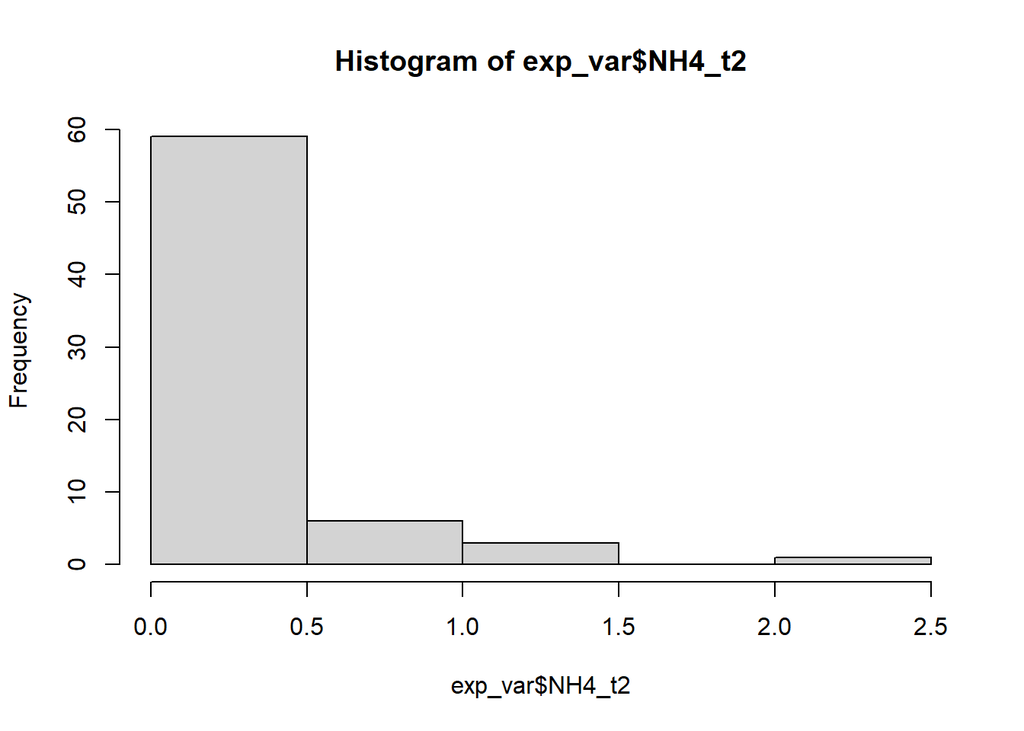

```r
hist(exp_var$NH4_t2)
```

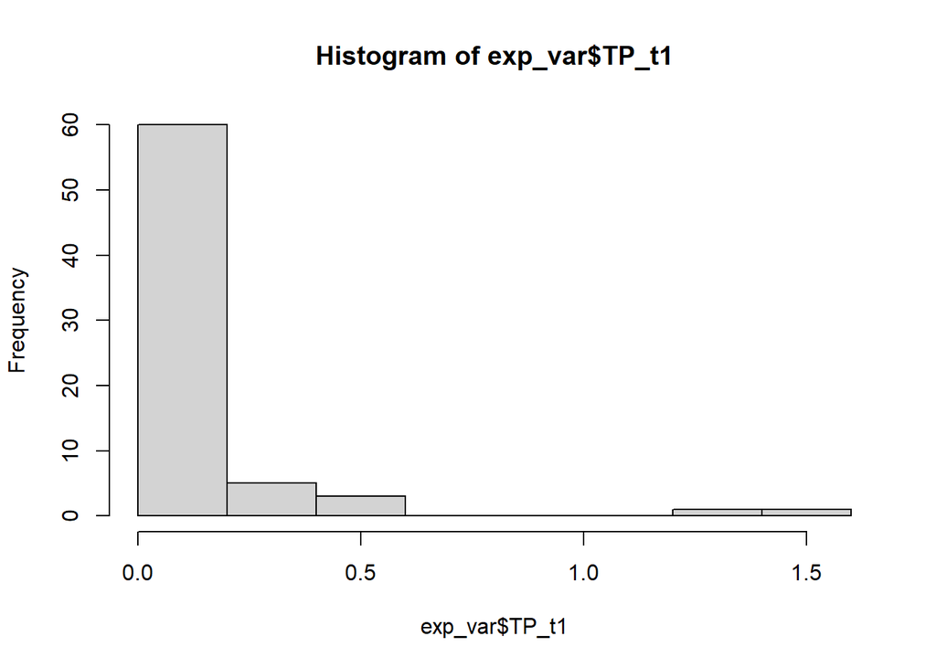

```r
hist(exp_var$TP_t1)
```

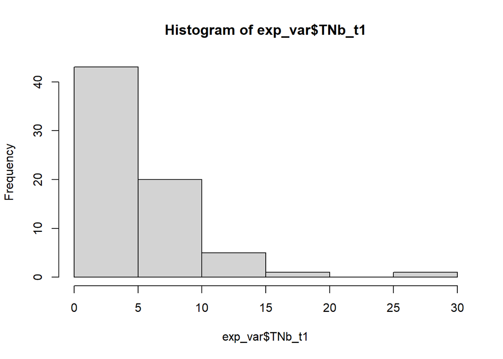

```r
hist(exp_var$TNb_t1)
```

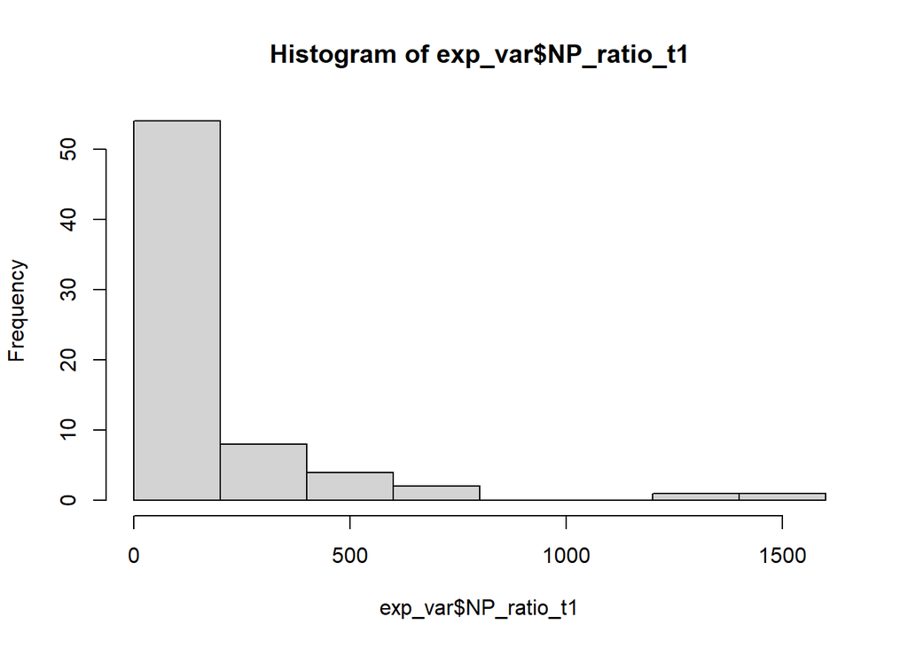

```r
hist(exp_var$NP_ratio_t1)
```

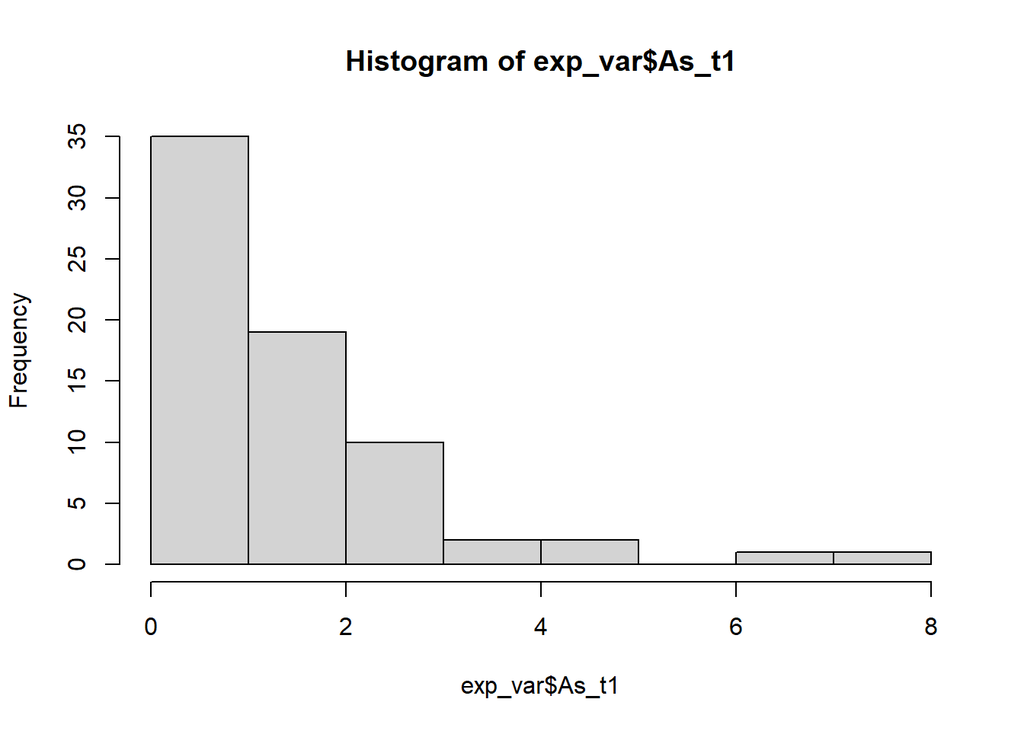

```r
hist(exp_var$As_t1)
```

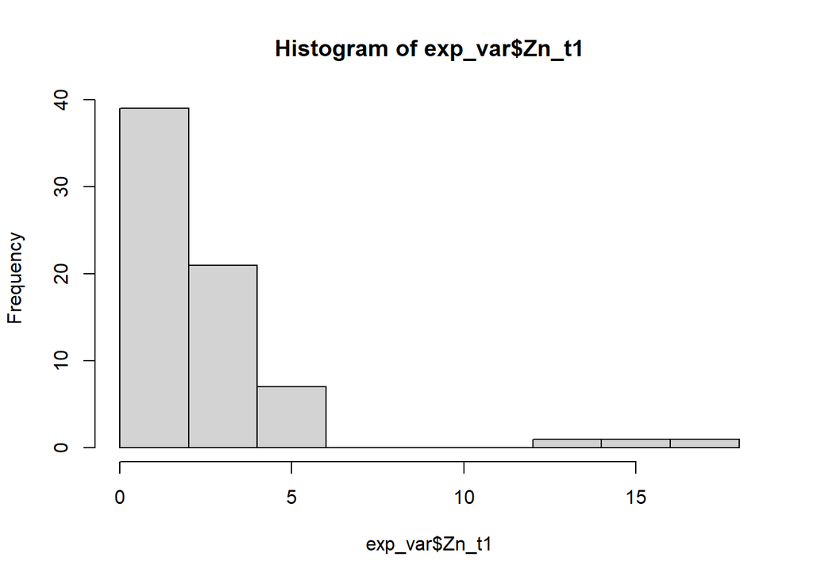

```r
hist(exp_var$Zn_t1)
```

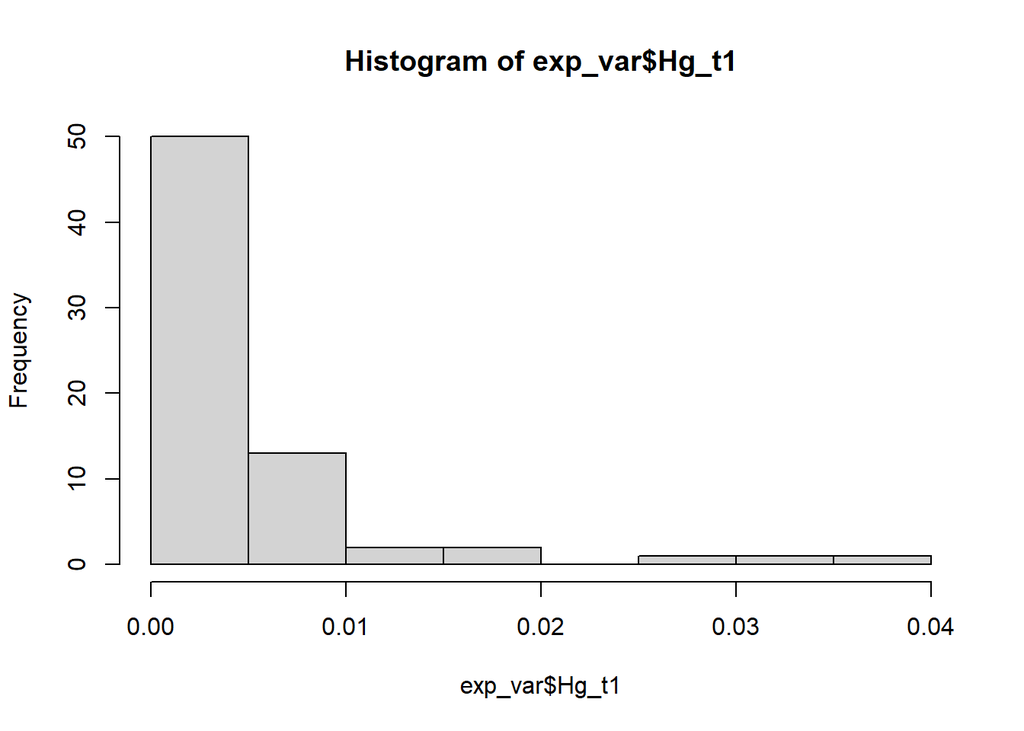

```r
hist(exp_var$Hg_t1)
```

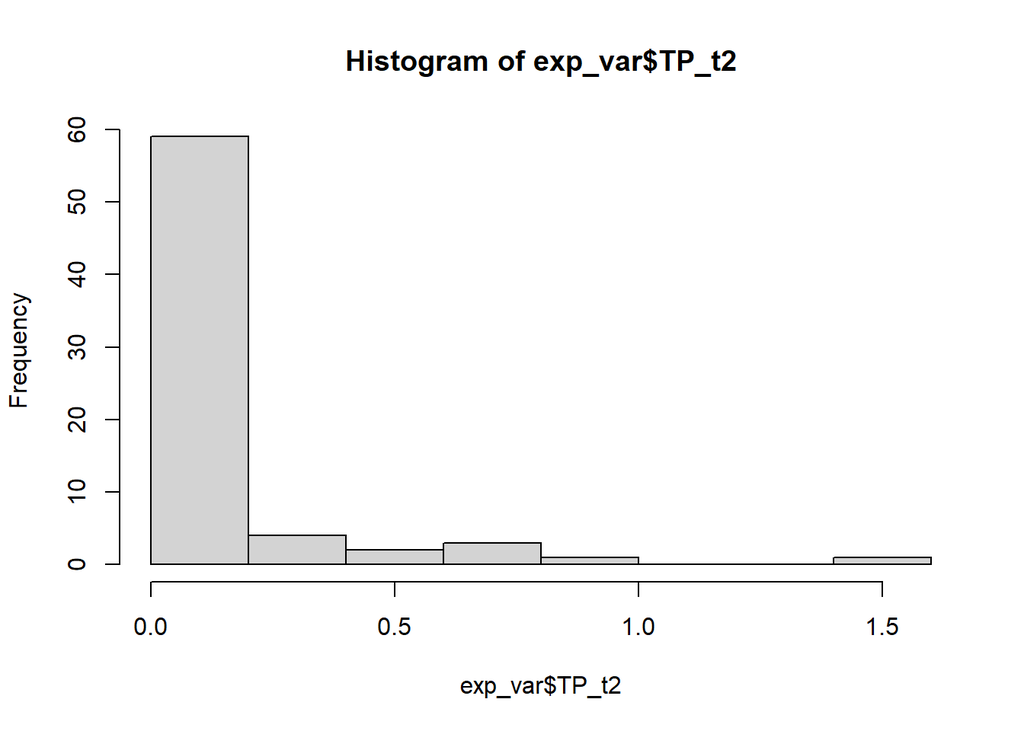

```r
hist(exp_var$TP_t2)
```

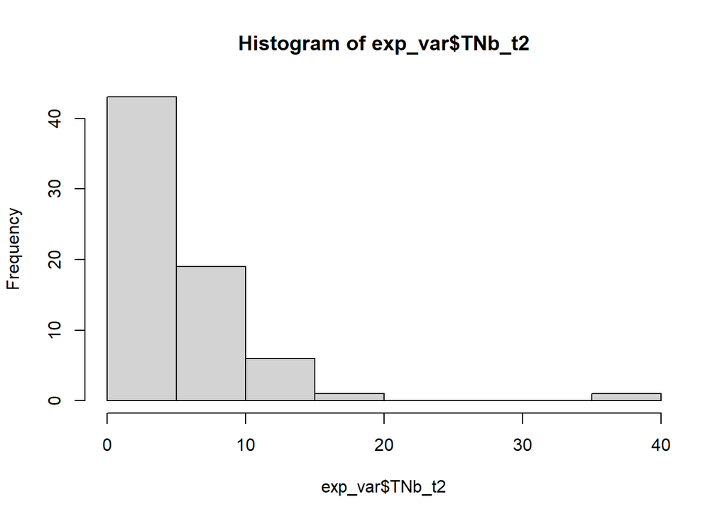

```r
hist(exp_var$TNb_t2)
```

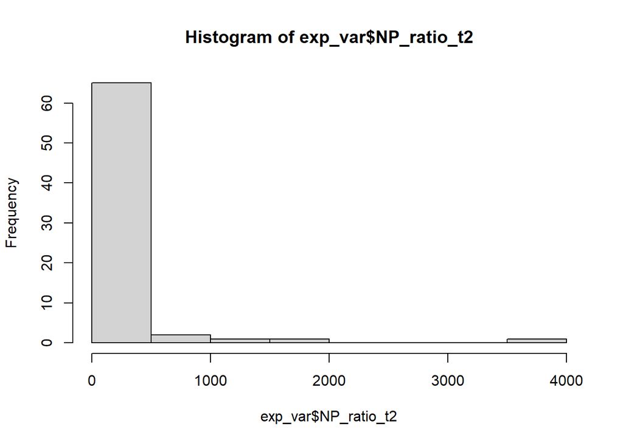

```r
hist(exp_var$NP_ratio_t2)
```

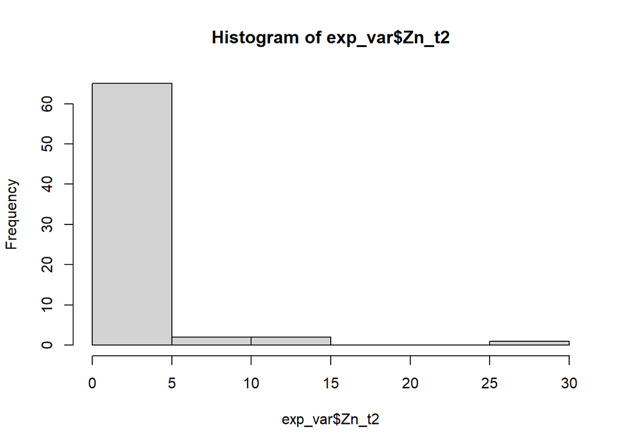

```r
hist(exp_var$Zn_t2)
```

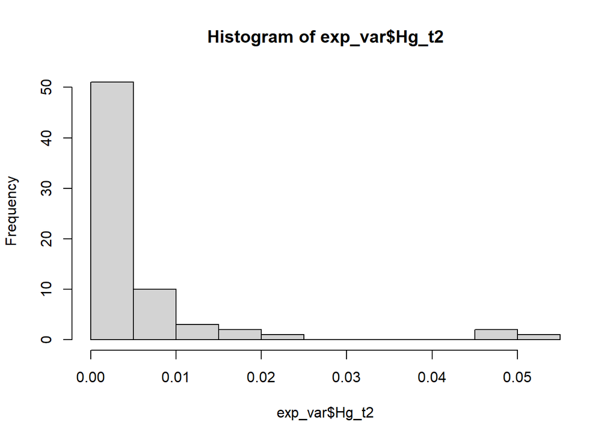

```r
hist(exp_var$Hg_t2)
```

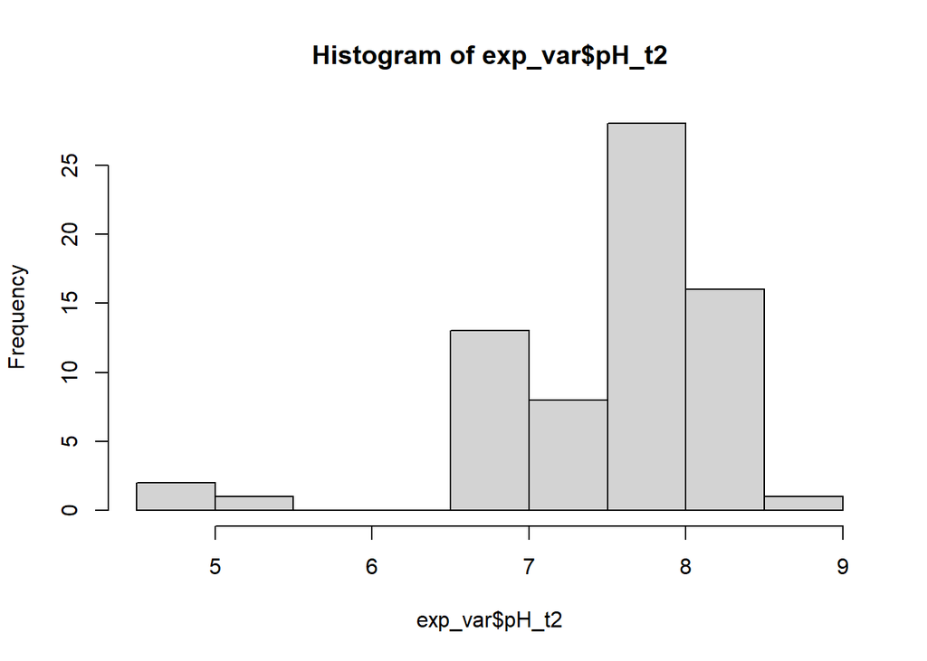

```r
hist(exp_var$pH_t2) # do not transform
```

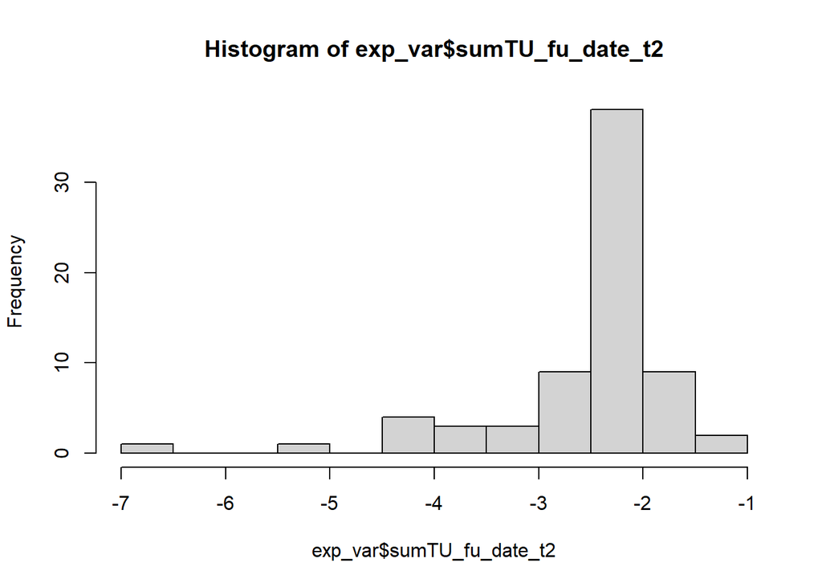

```r
hist(exp_var$sumTU_fu_date_t2) # don't transform sumTU, since this would be double transformed
```

for the other variables, a log transformation is required

```r
exp_var$area_tr <- log10(exp_var$area)
exp_var$CPOM_tr <- log10(exp_var$CPOM+1) # add 1 since 0 value cannot be log transformed
exp_var$abu_shr_tr <- log10(exp_var$abu_shr)
exp_var$NO3_t1_tr <- log10(exp_var$NO3_t1)
exp_var$PO4_t1_tr <- log10(exp_var$PO4_t1)
exp_var$NH4_t1_tr <- log10(exp_var$NH4_t1)
exp_var$NO2_t2_tr <- log10(exp_var$NO2_t2)
exp_var$NO3_t2_tr <- log10(exp_var$NO3_t2)
exp_var$PO4_t2_tr <- log10(exp_var$PO4_t2)
exp_var$NH4_t2_tr <- log10(exp_var$NH4_t2)
exp_var$TP_t1_tr <- log10(exp_var$TP_t1)
exp_var$TNb_t1_tr <- log10(exp_var$TNb_t1)
exp_var$NP_ratio_t1_tr <- log10(exp_var$NP_ratio_t1)
exp_var$As_t1_tr <- log10(exp_var$As_t1)
exp_var$Zn_t1_tr <- log10(exp_var$Zn_t1)
exp_var$Hg_t1_tr <- log10(exp_var$Hg_t1)
exp_var$TP_t2_tr <- log10(exp_var$TP_t2)
exp_var$TNb_t2_tr <- log10(exp_var$TNb_t2)
exp_var$NP_ratio_t2_tr <- log10(exp_var$NP_ratio_t2)
exp_var$Zn_t2_tr <- log10(exp_var$Zn_t2)
exp_var$Hg_t2_tr <- log10(exp_var$Hg_t2)
```

remove non-transformed variables from dataframe of explanatory variables

```r
rem_perc <- c("area", "CPOM", "abu_shr", "NO3_t1", "PO4_t1", "NH4_t1", "NO2_t2", "NO3_t2", "PO4_t2", "NH4_t2", "TP_t1", "TNb_t1", "NP_ratio_t1", "As_t1", "Zn_t1", "Hg_t1", "TP_t2", "TNb_t2", "NP_ratio_t2", "Zn_t2", "Hg_t2")

exp_var2 <- exp_var[ , -which(names(exp_var) %in% rem_perc)]
```

check if skewness improved

```r
data_perc <- exp_var2[,-1] # remove site ID

skew_perc <- NULL
for(i in 1:ncol(data_perc)) {
  colname <- names(data_perc)[i]
t <- skewness(select(data_perc, all_of(colname)), na.rm = TRUE)
skew_perc$variable[i] <- all_of(colname)
skew_perc$value[i] <- t
}

skew_perc <- as.data.frame(skew_perc)

# variables above values of 2 need to be transformed
var_transform <- skew_perc[sqrt((skew_perc$value)^2) > "2" , ]
var_transform$variable
```

```
## [1] "sumTU_fu_date_t2"
```

Yes, no other variables need to be transformed

## 5.3 collinearity check

correlation matrix make each a check per time point, as the same variable of both time points logically shows an intercorrelation

```r
var_t1 <- c("streamType", "ratio_agri","area_tr", "agri_buffer", "fine_sub", "speartaxa", "perc_shred", "abu_shr_tr", "CPOM_tr", "EC_t1", "O2_t1", "NO2_t1", "NO3_t1_tr", "PO4_t1_tr", "NH4_t1_tr", "TP_t1_tr", "TNb_t1_tr", "NP_ratio_t1_tr", "As_t1_tr", "Zn_t1_tr", "Hg_t1_tr", "Cu_t1", "pH_t1", "flow_t1", "sumTU_fu_date_t1", "sumTU_iv_date_t1")

exp_var_t1 <- exp_var2[ , which(names(exp_var2) %in% var_t1)]
```

```r
var_t2 <- c("streamType", "ratio_agri","area_tr", "agri_buffer", "fine_sub", "speartaxa", "perc_shred", "abu_shr_tr", "CPOM_tr", "EC_t2", "O2_t2", "NO2_t2_tr", "NO3_t2_tr", "PO4_t2_tr", "NH4_t2_tr", "TP_t2_tr", "TNb_t2_tr", "NP_ratio_t2_tr", "As_t2", "Zn_t2_tr", "Hg_t2_tr", "Cu_t2", "pH_t2", "flow_t2", "sumTU_fu_date_t2", "sumTU_iv_date_t2")

exp_var_t2 <- exp_var2[ , which(names(exp_var2) %in% var_t2)]
```

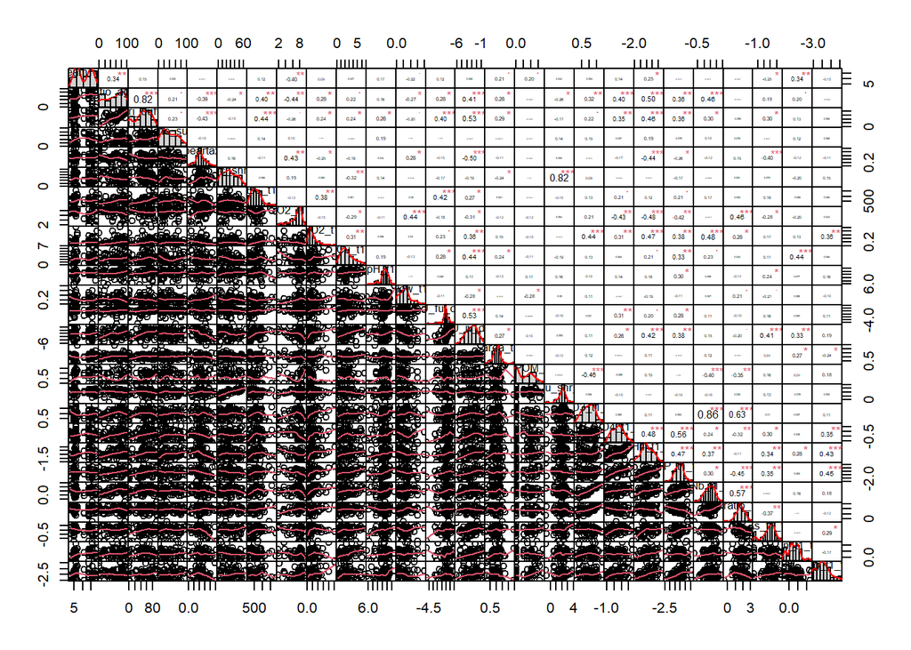

```r
# this one can handle NA values in the single variables
chart.Correlation(exp_var_t1, histogram=TRUE, pch=19)
```

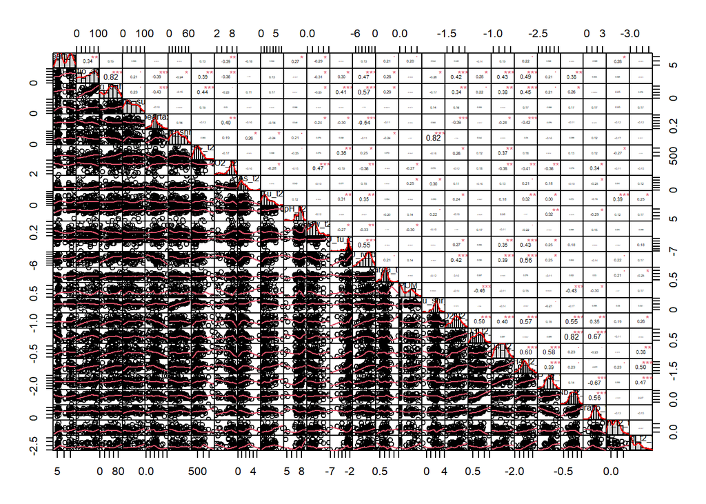

```r
chart.Correlation(exp_var_t2, histogram=TRUE, pch=19)
```

```r
var_t1 <- c("siteID", "streamType", "ratio_agri","area_tr", "fine_sub", "speartaxa", "perc_shred", "CPOM_tr", "EC_t1", "O2_t1", "NO2_t1", "PO4_t1_tr", "NH4_t1_tr", "TP_t1_tr", "TNb_t1_tr", "NP_ratio_t1_tr", "As_t1_tr", "Zn_t1_tr", "Hg_t1_tr", "Cu_t1", "pH_t1", "flow_t1", "sumTU_fu_date_t1", "sumTU_iv_date_t1")

exp_var_t1 <- exp_var2[ , which(names(exp_var2) %in% var_t1)]


var_t2 <- c("siteID", "streamType", "ratio_agri","area_tr", "fine_sub", "speartaxa", "perc_shred", "CPOM_tr", "EC_t2", "O2_t2", "NO2_t2_tr", "PO4_t2_tr", "NH4_t2_tr", "TP_t2_tr", "TNb_t2_tr", "NP_ratio_t2_tr", "As_t2", "Zn_t2_tr", "Hg_t2_tr", "Cu_t2", "pH_t2", "flow_t2", "sumTU_fu_date_t2", "sumTU_iv_date_t2")

exp_var_t2 <- exp_var2[ , which(names(exp_var2) %in% var_t2)]
```

VIF - variance inflation factor

```r
Decom_2019_t1 <- merge(Decom_2019_all, exp_var_t1, by=c("siteID"))

model_t1 <- lm(DSM_leaves ~ streamType + ratio_agri + fine_sub + area_tr + fine_sub + speartaxa + perc_shred + CPOM_tr + EC_t1 + O2_t1 + NO2_t1 + PO4_t1_tr + NH4_t1_tr + TP_t1_tr + TNb_t1_tr + NP_ratio_t1_tr + As_t1_tr + Zn_t1_tr + Hg_t1_tr + Cu_t1 + pH_t1 + flow_t1 + sumTU_fu_date_t1 + sumTU_iv_date_t1, data = Decom_2019_t1)
car::vif(model_t1)
```

```
##       streamType       ratio_agri         fine_sub          area_tr
##         3.516990         3.850656         2.216703         1.739458
##        speartaxa       perc_shred          CPOM_tr            EC_t1
##         2.567890         1.964956         2.230621         3.385556
##            O2_t1           NO2_t1        PO4_t1_tr        NH4_t1_tr
##         4.028887         2.938054         2.252613         3.058247
##         TP_t1_tr        TNb_t1_tr   NP_ratio_t1_tr         As_t1_tr
##         8.890143         8.660970        10.339696         4.661533
##         Zn_t1_tr         Hg_t1_tr            Cu_t1            pH_t1
##         2.839834         2.556556         2.532310         2.198518
##          flow_t1 sumTU_fu_date_t1 sumTU_iv_date_t1
##         3.910783         1.999940         3.967895
```

VIF of NP_ratio_t1_tr is higher than 10, remove this variable

```r
model_t1_2 <- lm(DSM_leaves ~ streamType + ratio_agri + fine_sub + area_tr + fine_sub + speartaxa + perc_shred + CPOM_tr + EC_t1 + O2_t1 + NO2_t1 + PO4_t1_tr + NH4_t1_tr + TP_t1_tr + TNb_t1_tr + As_t1_tr + Zn_t1_tr + Hg_t1_tr + Cu_t1 + pH_t1 + flow_t1 + sumTU_fu_date_t1 + sumTU_iv_date_t1, data = Decom_2019_t1)
car::vif(model_t1_2)
```

```
##       streamType       ratio_agri         fine_sub          area_tr
##         3.363966         3.840549         2.168806         1.609916
##        speartaxa       perc_shred          CPOM_tr            EC_t1
##         2.544655         1.827773         2.137502         2.881897
##            O2_t1           NO2_t1        PO4_t1_tr        NH4_t1_tr
##         3.900657         2.786930         2.247524         2.991745
##         TP_t1_tr        TNb_t1_tr         As_t1_tr         Zn_t1_tr
##         4.072295         3.432089         4.156759         2.839725
##         Hg_t1_tr            Cu_t1            pH_t1          flow_t1
##         2.508419         2.465854         2.193585         3.432868
## sumTU_fu_date_t1 sumTU_iv_date_t1
##         1.999618         3.948829
```

now VIF is fine (all clearly below 10, even below 5)

```r
Decom_2019_t2 <- merge(Decom_2019_all, exp_var_t2, by=c("siteID"))

model_t2 <- lm(DSM_leaves ~ streamType + ratio_agri + fine_sub + area_tr + fine_sub + speartaxa + perc_shred + CPOM_tr + EC_t2 + O2_t2 + NO2_t2_tr + PO4_t2_tr + NH4_t2_tr + TP_t2_tr + TNb_t2_tr + NP_ratio_t2_tr + As_t2 + Zn_t2_tr + Hg_t2_tr + Cu_t2 + pH_t2 + flow_t2 + sumTU_fu_date_t2 + sumTU_iv_date_t2, data = Decom_2019_t2)
car::vif(model_t2)
```

```
##       streamType       ratio_agri         fine_sub          area_tr
##         3.054607         3.855858         2.288102         2.002038
##        speartaxa       perc_shred          CPOM_tr            EC_t2
##         2.309435         2.380277         2.707076         3.290364
##            O2_t2        NO2_t2_tr        PO4_t2_tr        NH4_t2_tr
##         2.898850         4.213482         4.023512         3.825636
##         TP_t2_tr        TNb_t2_tr   NP_ratio_t2_tr            As_t2
##        21.531405        12.989631        26.382745         2.001423
##         Zn_t2_tr         Hg_t2_tr            Cu_t2            pH_t2
##         3.666894         4.789454         2.011996         2.207900
##          flow_t2 sumTU_fu_date_t2 sumTU_iv_date_t2
##         3.237510         2.417824         3.741374
```

VIF of TP, TN and the NP_ratio is higher than 10, remove NP_ratio

```r
model_t2_2 <- lm(DSM_leaves ~ streamType + ratio_agri + fine_sub + area_tr + fine_sub + speartaxa + perc_shred + CPOM_tr + EC_t2 + O2_t2 + NO2_t2_tr + PO4_t2_tr + NH4_t2_tr + TP_t2_tr + TNb_t2_tr + As_t2 + Zn_t2_tr + Hg_t2_tr + Cu_t2 + pH_t2 + flow_t2 + sumTU_fu_date_t2 + sumTU_iv_date_t2, data = Decom_2019_t2)
car::vif(model_t2_2)
```

```
##       streamType       ratio_agri         fine_sub          area_tr
##         3.052632         3.329528         1.697239         1.614428
##        speartaxa       perc_shred          CPOM_tr            EC_t2
##         2.023303         2.306611         2.707060         3.007991
##            O2_t2        NO2_t2_tr        PO4_t2_tr        NH4_t2_tr
##         2.841501         3.911589         3.906312         3.809236
##         TP_t2_tr        TNb_t2_tr            As_t2         Zn_t2_tr
##         3.481068         2.911269         1.943401         3.411522
##         Hg_t2_tr            Cu_t2            pH_t2          flow_t2
##         2.443462         1.944181         2.163727         2.805570
## sumTU_fu_date_t2 sumTU_iv_date_t2
##         2.344469         3.682032
```

now VIF is fine (all clearly below 10, even below 5)

# 6 identify environmental variables driving the decomposition measured via different substrates

we are using the stability selection approach, since this approach reduces the number of false selected variables

## 6.1 microbial leaf decomposition

create subset of samples without NAs in the response variable microbial leaf decomposition

```r
Decom_2019_leaves <- Decom_2019_t1[!is.na(Decom_2019_t1$DSM_leaves), ]
# for leaves 182 data points
```

select explanatory variables

```r
# all used explanatory variables
var_en_t1 <- c("streamType", "ratio_agri","area_tr", "fine_sub", "NO2_t1", "PO4_t1_tr", "NH4_t1_tr", "TP_t1_tr", "TNb_t1_tr", "As_t1_tr", "Zn_t1_tr", "Hg_t1_tr", "Cu_t1", "pH_t1", "flow_t1", "sumTU_fu_date_t1", "O2_t1", "EC_t1")

data_en_leaves <- Decom_2019_leaves[ , which(names(Decom_2019_leaves) %in% var_en_t1)]
```

remove the variables EC and O2, due to missing values (NA). See in previous version, results where these variables were included (before change of package), results are similar

```r
data_en_leaves <- data_en_leaves[, -c(4,5)]
```

conduct a stability selection –> calculate probability that a variable is selected we use 0.7 (70%) as cutoff point

```r
set.seed(123) # set seed to enable better reproducibility (still not 100% reproducibility)
(stab.lasso <- stabsel(x = data_en_leaves, y = res_leaves,
                             fitfun = glmnet.lasso, cutoff = 0.7,
                             PFER = 1))
```

```
##  Stability Selection with unimodality assumption
##
## Selected variables:
## ratio_agri    flow_t1   As_t1_tr
##          2          7         14
##
## Selection probabilities:
##       streamType           NO2_t1 sumTU_fu_date_t1        TNb_t1_tr
##             0.00             0.00             0.00             0.00
##         fine_sub            pH_t1        PO4_t1_tr        NH4_t1_tr
##             0.01             0.01             0.01             0.01
##         TP_t1_tr          area_tr         Zn_t1_tr            Cu_t1
##             0.01             0.04             0.05             0.09
##         Hg_t1_tr       ratio_agri         As_t1_tr          flow_t1
##             0.11             0.76             0.80             0.98
##
## ---
## Cutoff: 0.7; q: 3; PFER (*):  0.721
##    (*) or expected number of low selection probability variables
## PFER (specified upper bound):  1
## PFER corresponds to signif. level 0.0451 (without multiplicity adjustment)
```

variables selected: As_t1_tr, flow_t1, ratio_agri

## 6.2 cotton strips

create subset of samples without NAs in the response variable leaf decomposition

```r
Decom_2019_cotton <- Decom_2019_t1[!is.na(Decom_2019_t1$Tens_loss), ]
# 152 observations
```

select explanatory variables

```r
# all used explanatory variables
data_en_cotton <- Decom_2019_cotton[ , which(names(Decom_2019_cotton) %in% var_en_t1)]
```

remove the variables EC and O2, due to missing values (NA). See in previous version, results where these variables were included (before change of package), results are similar

```r
data_en_cotton <- data_en_cotton[, -c(4,5)]
```

conduct a stability selection –> calculate probability that a variable is selected we use 0.7 (70%) as cutoff point

```r
set.seed(123) # set seed to enable better reproducibility (still not 100% reproducibility)
(stab.lasso_cotton <- stabsel(x = data_en_cotton, y = res_cotton,
                             fitfun = glmnet.lasso, cutoff = 0.7,
                             PFER = 1))
```

```
##  Stability Selection with unimodality assumption
##
## Selected variables:
## ratio_agri
##          2
##
## Selection probabilities:
##            Cu_t1         Zn_t1_tr           NO2_t1          flow_t1
##             0.00             0.00             0.01             0.01
##       streamType         fine_sub         Hg_t1_tr            pH_t1
##             0.02             0.02             0.02             0.04
##         As_t1_tr          area_tr        PO4_t1_tr sumTU_fu_date_t1
##             0.04             0.09             0.11             0.25
##        NH4_t1_tr         TP_t1_tr        TNb_t1_tr       ratio_agri
##             0.36             0.43             0.51             0.85
##
## ---
## Cutoff: 0.7; q: 3; PFER (*):  0.721
##    (*) or expected number of low selection probability variables
## PFER (specified upper bound):  1
## PFER corresponds to signif. level 0.0451 (without multiplicity adjustment)
```

variables selected: ratio_agri

## 6.3 microbial decotabs

create subset of samples without NAs in the response variable leaf decomposition

```r
Decom_2019_dec <- Decom_2019_t1[!is.na(Decom_2019_t1$DSM_Decotabs), ]
# 173 observations
```

select explanatory variables

```r
# all used explanatory variables
data_en_dec <- Decom_2019_dec[ , which(names(Decom_2019_dec) %in% var_en_t1)]
```

separate explanatory and response variables

```r
#  explanatory variables need to be Decom_2019_cotton
res_dec <- as.matrix(select(Decom_2019_dec, DSM_Decotabs))  # --> response variable -> y
data_en_dec <- scale(as.matrix(data_en_dec)) # --> explanatory variables -> x
```

remove the variables EC and O2, due to missing values (NA). See in previous version, results where these variables were included (before change of package), results are similar

```r
data_en_dec <- data_en_dec[, -c(4,5)]
```

conduct a stability selection –> calculate probability that a variable is selected we use 0.7 (70%) as cutoff point

```r
set.seed(123) # set seed to enable better reproducibility (still not 100% reproducibility)
(stab.lasso_dec <- stabsel(x = data_en_dec, y = res_dec,
                             fitfun = glmnet.lasso, cutoff = 0.7,
                             PFER = 1))
```

```
##  Stability Selection with unimodality assumption
##
## Selected variables:
## sumTU_fu_date_t1
##                8
##
## Selection probabilities:
##        PO4_t1_tr        NH4_t1_tr       streamType       ratio_agri
##             0.00             0.00             0.01             0.02
##          flow_t1            Cu_t1          area_tr         Hg_t1_tr
##             0.02             0.03             0.08             0.08
##            pH_t1           NO2_t1        TNb_t1_tr         fine_sub
##             0.09             0.14             0.14             0.19
##         Zn_t1_tr         TP_t1_tr         As_t1_tr sumTU_fu_date_t1
##             0.26             0.28             0.63             0.78
##
## ---
## Cutoff: 0.7; q: 3; PFER (*):  0.721
##    (*) or expected number of low selection probability variables
## PFER (specified upper bound):  1
## PFER corresponds to signif. level 0.0451 (without multiplicity adjustment)
```

variables selected: sumTU_fu_date_t1

## 6.4 total leaf decomposition

create subset of samples without NAs in the response variable leaf decomposition

```r
Decom_2019_leaves_coarse <- Decom_2019_t2[!is.na(Decom_2019_t2$DSM_leaves_coarse), ]
# for leaves_coarse 169 data points
```

select explanatory variables

```r
# all used explanatory variables
var_en_t2 <- c("streamType", "ratio_agri","area_tr", "fine_sub", "NO2_t2_tr", "PO4_t2_tr", "NH4_t2_tr", "TP_t2_tr", "TNb_t2_tr", "As_t2", "Zn_t2_tr", "Hg_t2_tr", "Cu_t2", "pH_t2", "flow_t2", "sumTU_fu_date_t2", "sumTU_iv_date_t2", "CPOM_tr", "perc_shred", "speartaxa", "O2_t2", "EC_t2")

data_en_leaves_coarse <- Decom_2019_leaves_coarse[ , which(names(Decom_2019_leaves_coarse) %in% var_en_t2)]
```

remove the variables EC and O2, due to missing values (NA). Remove three entries of missing nutrient values See in previous version, results where these variables were included (before change of package), results are similar

```r
data_en_leaves_coarse <- data_en_leaves_coarse[, -c(6,7)]
data_en_leaves_coarse <- data_en_leaves_coarse[-c(32,33,34), ]
```

conduct a stability selection –> calculate probability that a variable is selected we use 0.7 (70%) as cutoff point

```r
set.seed(123) # set seed to enable better reproducibility (still not 100% reproducibility)
(stab.lasso_leaves_coarse <- stabsel(x = data_en_leaves_coarse, y = res_leaves_coarse[-c(32,33,34)],
                             fitfun = glmnet.lasso, cutoff = 0.7,
                             PFER = 1))
```

```
##  Stability Selection with unimodality assumption
##
## Selected variables:
## speartaxa
##         4
##
## Selection probabilities:
##            pH_t2        NO2_t2_tr        PO4_t2_tr         fine_sub
##             0.00             0.00             0.00             0.01
##         TP_t2_tr            As_t2            Cu_t2          flow_t2
##             0.01             0.02             0.02             0.02
## sumTU_fu_date_t2         Hg_t2_tr sumTU_iv_date_t2          CPOM_tr
##             0.02             0.02             0.03             0.03
##        NH4_t2_tr       streamType         Zn_t2_tr       perc_shred
##             0.04             0.12             0.15             0.23
##        TNb_t2_tr       ratio_agri          area_tr        speartaxa
##             0.32             0.37             0.44             0.75
##
## ---
## Cutoff: 0.7; q: 3; PFER (*):  0.577
##    (*) or expected number of low selection probability variables
## PFER (specified upper bound):  1
## PFER corresponds to signif. level 0.0288 (without multiplicity adjustment)
```

variables selected: speartaxa

## 6.5 total decotabs

create subset of samples without NAs in the response variable leaf decomposition

```r
Decom_2019_dec_coarse <- Decom_2019_t1[!is.na(Decom_2019_t1$DSM_Decotabs_coarse), ]
# 80 observations
```

select explanatory variables

```r
# all used explanatory variables
var_en_t1_macro <- c("streamType", "ratio_agri","area_tr", "fine_sub", "NO2_t1", "PO4_t1_tr", "NH4_t1_tr", "TP_t1_tr", "TNb_t1_tr", "As_t1_tr", "Zn_t1_tr", "Hg_t1_tr", "Cu_t1", "pH_t1", "flow_t1", "sumTU_fu_date_t1", "sumTU_iv_date_t1", "CPOM_tr", "perc_shred", "speartaxa", "O2_t1", "EC_t1")

data_en_dec_coarse <- Decom_2019_dec_coarse[ , which(names(Decom_2019_dec_coarse) %in% var_en_t1_macro)]
```

remove the variables EC and O2, due to missing values (NA). See in previous version, results where these variables were included (before change of package), results are similar

```r
data_en_dec_coarse <- data_en_dec_coarse[, -c(6,7)]
```

conduct a stability selection –> calculate probability that a variable is selected we use 0.7 (70%) as cutoff point

```r
set.seed(123) # set seed to enable better reproducibility (still not 100% reproducibility)
(stab.lasso_dec_coarse <- stabsel(x = data_en_dec_coarse, y = res_dec_coarse,
                             fitfun = glmnet.lasso, cutoff = 0.7,
                             PFER = 1))
```

```
##  Stability Selection with unimodality assumption
##
## Selected variables:
## TP_t1_tr
##       16
##
## Selection probabilities:
##       streamType            Cu_t1        TNb_t1_tr         As_t1_tr
##             0.00             0.00             0.00             0.00
##         Zn_t1_tr        speartaxa       perc_shred          flow_t1
##             0.00             0.01             0.01             0.02
##          CPOM_tr          area_tr        PO4_t1_tr         fine_sub
##             0.02             0.03             0.04             0.09
##           NO2_t1            pH_t1        NH4_t1_tr       ratio_agri
##             0.11             0.13             0.13             0.15
## sumTU_fu_date_t1         Hg_t1_tr sumTU_iv_date_t1         TP_t1_tr
##             0.19             0.42             0.65             0.84
##
## ---
## Cutoff: 0.7; q: 3; PFER (*):  0.577
##    (*) or expected number of low selection probability variables
## PFER (specified upper bound):  1
## PFER corresponds to signif. level 0.0288 (without multiplicity adjustment)
```

## 6.6 create Figure S3

create dataframe with all explanatory variables (also not transformed to facilitate the plots)

```r
Decom_all <- merge(Decom_2019_all, exp_var, by=c("siteID"))
```

create linear models with all explanatory variables

Plot S3A: leaves vs. flow velocity

```r
Decom_all_leaves <- Decom_all[!is.na(Decom_all$DSM_leaves), ]
m1 <- lm(DSM_leaves ~ streamType + log10(area) + ratio_agri + fine_sub + O2_t1 + pH_t1 + EC_t1 + flow_t1 + sumTU_fu_date_t1 + log10(PO4_t1) + NO2_t1 + log10(NH4_t1) + log10(TP_t1) + log10(TNb_t1)  + log10(As_t1) + Cu_t1 + log10(Hg_t1) + log10(Zn_t1) , data = Decom_all_leaves)
g1_flow <- ggpredict(m1, terms = "flow_t1")
p1 <- plot(g1_flow)+
  ggtitle("") +
  ylab("Decomposed leaf mass [%] per dday")+
  xlab("Flow velocity [m/sec]") +
  labs(subtitle = "A") +
  geom_line(size=1.5)+
  theme_classic()+
  theme(axis.text.x = element_text(colour="black", size = 12),
        axis.text.y = element_text(colour="black", size = 12),
        plot.subtitle = element_text(colour="black", size = 14),
        legend.position="none", strip.text.x = element_text(face = "bold"),
        text = element_text(size=11), plot.title = element_text(hjust = 0.5))
```

Plot S3 B: leaves vs. arsenic

```r
g1_As <- ggpredict(m1, terms = "As_t1")
p2 <- plot(g1_As)+
  ggtitle("") +
  ylab("Decomposed leaf mass [%] per dday")+
  xlab("Arsenic [mg/L]") +
  scale_x_log10() +
  labs(subtitle = "B") +
  geom_line(size=1.5)+
  theme_classic()+
  theme(axis.text.x = element_text(colour="black", size = 12),
        axis.text.y = element_text(colour="black", size = 12),
        plot.subtitle = element_text(colour="black", size = 14),
        legend.position="none", strip.text.x = element_text(face = "bold"),
        text = element_text(size=11), plot.title = element_text(hjust = 0.5))
```

Plot S3 C: leaves vs. ratio agriculture

```r
g1_agri <- ggpredict(m1, terms = "ratio_agri")
p3 <- plot(g1_agri)+
  ggtitle("") +
  ylab("Decomposed leaf mass [%] per dday")+
  xlab("Agriculture catchment [%]") +
  labs(subtitle = "C") +
  geom_line(size=1.5)+
  theme_classic()+
  theme(axis.text.x = element_text(colour="black", size = 12),
        axis.text.y = element_text(colour="black", size = 12),
        plot.subtitle = element_text(colour="black", size = 14),
        legend.position="none", strip.text.x = element_text(face = "bold"),
        text = element_text(size=11), plot.title = element_text(hjust = 0.5))
```

Plot S3 D: cotton strips vs. ratio agriculture

```r
Decom_all_cotton <- Decom_all[!is.na(Decom_all$Tens_loss), ]
m2 <- lm(Tens_loss ~ streamType + log10(area) + ratio_agri + fine_sub + O2_t1 + pH_t1 + EC_t1 + flow_t1 + sumTU_fu_date_t1 + log10(PO4_t1) + NO2_t1 + log10(NH4_t1) + log10(TP_t1) + log10(TNb_t1)  + log10(As_t1) + Cu_t1 + log10(Hg_t1) + log10(Zn_t1) , data = Decom_all_cotton)
g2_agri <- ggpredict(m2, terms = "ratio_agri")
p4 <- plot(g2_agri)+
  ggtitle("") +
  ylab("Tension loss [%] per dday")+
  xlab("Agriculture catchment [%]") +
  labs(subtitle = "D") +
  geom_line(size=1.5)+
  theme_classic()+
  theme(axis.text.x = element_text(colour="black", size = 12),
        axis.text.y = element_text(colour="black", size = 12),
        plot.subtitle = element_text(colour="black", size = 14),
        legend.position="none", strip.text.x = element_text(face = "bold"),
        text = element_text(size=11), plot.title = element_text(hjust = 0.5))
```

Plot S3 E: decotabs vs. sumTUfungi

```r
Decom_all_deco <- Decom_all[!is.na(Decom_all$DSM_Decotabs), ]
m3 <- lm(DSM_Decotabs ~ streamType + log10(area) + ratio_agri + fine_sub + O2_t1 + pH_t1 + EC_t1 + flow_t1 + sumTU_fu_date_t1 + log10(PO4_t1) + NO2_t1 + log10(NH4_t1) + log10(TP_t1) + log10(TNb_t1)  + log10(As_t1) + Cu_t1 + log10(Hg_t1) + log10(Zn_t1), data = Decom_all_deco)
g3_sumfu <- ggpredict(m3, terms = "sumTU_fu_date_t1")
p5 <- plot(g3_sumfu)+
  ggtitle("") +
  ylab("Decomposed decotabs mass [%] per dday")+
  xlab("sumTU for fungi") +
  labs(subtitle = "E") +
  geom_line(size=1.5)+
  theme_classic()+
  theme(axis.text.x = element_text(colour="black", size = 12),
        axis.text.y = element_text(colour="black", size = 12),
        plot.subtitle = element_text(colour="black", size = 14),
        legend.position="none", strip.text.x = element_text(face = "bold"),
        text = element_text(size=11), plot.title = element_text(hjust = 0.5))
```

Plot S3 F: leaves total decomposition vs speartaxa

```r
Decom_all_leaves_coarse <- Decom_all[!is.na(Decom_all$DSM_leaves_coarse), ]

m4 <- lm(DSM_leaves_coarse ~ streamType + log10(area) + ratio_agri + fine_sub + O2_t2 + pH_t2 + EC_t2 + flow_t2 + sumTU_fu_date_t2 + log10(PO4_t2) + log10(NO2_t2) + log10(NH4_t2) + log10(TP_t2) + log10(TNb_t2)  + As_t2 + Cu_t2 + log10(Hg_t2) + log10(Zn_t2) + sumTU_iv_date_t2 + CPOM + speartaxa + perc_shred, data = Decom_all_leaves_coarse)

g4_spear <- ggpredict(m4, terms = "speartaxa")
p6 <- plot(g4_spear)+
  ggtitle("") +
  ylab(expression(atop("Total decomposed leaf mass [%]", paste("per dday"))))+
  xlab(expression("SPEAR" [pesticides])) +
  labs(subtitle = "F") +
  geom_line(size=1.5)+
  theme_classic()+
  theme(axis.text.x = element_text(colour="black", size = 12),
        axis.text.y = element_text(colour="black", size = 12),
        plot.subtitle = element_text(colour="black", size = 14),
        legend.position="none", strip.text.x = element_text(face = "bold"),
        text = element_text(size=11), plot.title = element_text(hjust = 0.5))
```

Plot S3 G: decotabs total decomposition vs. TP

```r
Decom_all_deco_coarse <- Decom_all[!is.na(Decom_all$DSM_Decotabs_coarse), ]

m5 <- lm(DSM_Decotabs_coarse ~ streamType + log10(area) + ratio_agri + fine_sub + O2_t1 + pH_t1 + EC_t1 + flow_t1 + sumTU_fu_date_t1 + log10(PO4_t1) + NO2_t1 + log10(NH4_t1) + log10(TP_t1) + log10(TNb_t1)  + log10(As_t1) + Cu_t1 + log10(Hg_t1) + log10(Zn_t1) + CPOM + sumTU_iv_date_t1 + speartaxa + perc_shred, data = Decom_all_deco_coarse)

g5_TP <- ggpredict(m5, terms = "TP_t1")
p7 <- plot(g5_TP)+
  ggtitle("") +
  ylab(expression(atop("Total decomposed decotabs mass [%]", paste("per dday"))))+
  xlab("Total phosphorus [mg/L]") +
  scale_x_log10() +
  labs(subtitle = "G") +
  geom_line(size=1.5)+
  theme_classic()+
  theme(axis.text.x = element_text(colour="black", size = 12),
        axis.text.y = element_text(colour="black", size = 12),
        plot.subtitle = element_text(colour="black", size = 14),
        legend.position="none", strip.text.x = element_text(face = "bold"),
        text = element_text(size=11), plot.title = element_text(hjust = 0.5))
```

Fig S3 H: total decotabs vs. sumTUinvertebrates

```r
g5_sumTUiv <- ggpredict(m5, terms = "sumTU_iv_date_t1")
p8 <- plot(g5_sumTUiv)+
  ggtitle("") +
  ylab(expression(atop("Total decomposed decotabs mass [%]", paste("per dday"))))+
  xlab("sumTU for invertebrates") +
  labs(subtitle = "H") +
  geom_line(size=1.5)+
  theme_classic()+
  theme(axis.text.x = element_text(colour="black", size = 12),
        axis.text.y = element_text(colour="black", size = 12),
        plot.subtitle = element_text(colour="black", size = 14),
        legend.position="none", strip.text.x = element_text(face = "bold"),
        text = element_text(size=11), plot.title = element_text(hjust = 0.5))
```

save plot

```r
png(filename="Figure_S3_effects_plots.png", width=9, height=12.5, units="in", res = 1000)
# arrange via cowplot
ggdraw() +
  draw_plot(p1, x = 0, y = 0.75, width = 0.5, height = 0.25) +
  draw_plot(p2, x = 0.5, y = 0.75, width = 0.5, height = 0.25) +
  draw_plot(p3, x = 0, y = 0.5, width = 0.5, height = 0.25) +
  draw_plot(p4, x = 0.5, y = 0.5, width = 0.5, height = 0.25)+
  draw_plot(p5, x = 0, y = 0.25, width = 0.5, height = 0.25) +
  draw_plot(p6, x = 0.5, y = 0.25, width = 0.5, height = 0.25) +
  draw_plot(p7, x = 0, y = 0, width = 0.5, height = 0.25) +
  draw_plot(p8, x = 0.5, y = 0, width = 0.5, height = 0.25)
dev.off()
```